# HOMEWORK 1

**REMEMBER: Assignments that do not complete all of the above will receive a pending score, which will require you to resubmit your work and cost you a token.**

### Helpful Suggestions

- When developing your code, use print statements liberally to understand what is happening. Printing out values helps you understand the flow of the code, as well as whether your logic makes sense.
- Pay careful attention to all specifications and directions. In general, 10-20\% of students on the first assignment must redo it, and it is almost always because they fail to read the directions and specifications carefully.
- IMPORTANT: do not just dump all your analysis into your submission. Instead, include only what makes sense for me to read, and that supports the specifications.
- Include plenth of comments in your analysis that identifies which problem you are completing. The comments must also answer any questions that are in the specifications.

## GENERAL SPECIFICATIONS (FOR ALL PROBLEMS)

- **Make sure to read ALL specifications. Remember: you must complete all specifications to complete the assignment.**
- You must use the responses dataset.
- Data must be read into a pandas dataframe.
- You must submit a **NEW** Jupyter Notebook. Do NOT insert your code into *this* notebook!
- Each Problem must be clearly labeled using a markdown cell (e.g., Problem 1, Problem 2)

## Problem 1: Pandas

### SPECIFICATIONS

- Read in the responses.csv file
- Create a subsetted dataframe called df2. This dataframe will be used for the rest of the assignment, and must include the following columns: 'Music', 'Slow songs or fast songs', 'Dance', 'Folk', 'Country', 'Classical music', 'Musical', 'Pop', 'Rock', 'Metal or Hardrock'
- Rename the last column to 'HardRock'
- Create a new GenderCode column, which lists women as 0 and men as 1.
- Run the mean for HardRock, grouping by your new gendercode variable.

```python
import pandas as pd # to refer to pandas as pd now

df = pd.read_csv('responses.csv') # read into a pandas data frame
```

```python
# create a new dataframe with a subset of columns
cols = ['Music', 'Slow songs or fast songs', 'Dance',\
        'Folk', 'Country', 'Classical music', 'Musical',\
        'Pop', 'Rock', 'Metal or Hardrock']
df2 = df.loc[:,cols].copy() # all rows (:)
df2
```

|  | Music | Slow songs or fast songs | Dance | Folk | Country | Classical music | Musical | Pop | Rock | Metal or Hardrock |
| --- | --- | --- | --- | --- | --- | --- | --- | --- | --- | --- |
| 0 | 5.0 | 3.0 | 2.0 | 1.0 | 2.0 | 2.0 | 1.0 | 5.0 | 5.0 | 1.0 |
| 1 | 4.0 | 4.0 | 2.0 | 1.0 | 1.0 | 1.0 | 2.0 | 3.0 | 5.0 | 4.0 |
| 2 | 5.0 | 5.0 | 2.0 | 2.0 | 3.0 | 4.0 | 5.0 | 3.0 | 5.0 | 3.0 |
| 3 | 5.0 | 3.0 | 2.0 | 1.0 | 1.0 | 1.0 | 1.0 | 2.0 | 2.0 | 1.0 |
| 4 | 5.0 | 3.0 | 4.0 | 3.0 | 2.0 | 4.0 | 3.0 | 5.0 | 3.0 | 1.0 |
| 5 | 5.0 | 3.0 | 2.0 | 3.0 | 2.0 | 3.0 | 3.0 | 2.0 | 5.0 | 5.0 |
| 6 | 5.0 | 5.0 | 5.0 | 3.0 | 1.0 | 2.0 | 2.0 | 5.0 | 3.0 | 1.0 |
| 7 | 5.0 | 3.0 | 3.0 | 2.0 | 1.0 | 2.0 | 2.0 | 4.0 | 5.0 | 1.0 |
| 8 | 5.0 | 3.0 | 3.0 | 1.0 | 1.0 | 2.0 | 4.0 | 3.0 | 5.0 | 5.0 |
| 9 | 5.0 | 3.0 | 2.0 | 5.0 | 2.0 | 2.0 | 5.0 | 3.0 | 5.0 | 2.0 |
| 10 | 5.0 | 3.0 | 3.0 | 2.0 | 1.0 | 2.0 | 3.0 | 4.0 | 3.0 | 2.0 |
| 11 | 5.0 | 3.0 | 1.0 | 1.0 | 1.0 | 4.0 | 1.0 | 2.0 | 5.0 | 1.0 |
| 12 | 5.0 | 3.0 | 1.0 | 2.0 | 1.0 | 4.0 | 3.0 | 3.0 | 5.0 | 4.0 |
| 13 | 5.0 | 3.0 | 5.0 | 3.0 | 2.0 | 1.0 | 5.0 | 5.0 | 2.0 | 1.0 |
| 14 | 5.0 | 3.0 | 2.0 | 1.0 | 1.0 | 2.0 | 3.0 | 4.0 | 5.0 | 2.0 |
| 15 | 1.0 | 3.0 | 2.0 | 2.0 | 3.0 | 4.0 | 3.0 | 3.0 | 5.0 | 5.0 |
| 16 | 5.0 | 3.0 | 3.0 | 1.0 | 1.0 | 1.0 | 2.0 | 4.0 | 4.0 | 1.0 |
| 17 | 5.0 | 3.0 | 3.0 | 3.0 | 3.0 | 2.0 | 2.0 | 4.0 | 4.0 | 2.0 |
| 18 | 5.0 | 3.0 | 5.0 | 4.0 | 3.0 | 4.0 | 5.0 | 5.0 | 4.0 | 4.0 |
| 19 | 5.0 | 4.0 | 3.0 | 3.0 | 2.0 | 4.0 | 2.0 | 2.0 | 4.0 | 5.0 |
| 20 | 5.0 | 3.0 | 3.0 | 2.0 | 3.0 | 4.0 | 3.0 | 2.0 | 5.0 | 5.0 |
| 21 | 5.0 | 5.0 | 1.0 | 1.0 | 3.0 | 2.0 | 2.0 | 2.0 | 5.0 | 5.0 |
| 22 | 5.0 | 3.0 | 3.0 | 2.0 | 3.0 | 3.0 | 3.0 | 4.0 | NaN | 1.0 |
| 23 | 5.0 | 3.0 | 4.0 | 2.0 | 2.0 | 2.0 | 4.0 | 4.0 | 5.0 | 2.0 |
| 24 | 5.0 | 2.0 | 3.0 | 1.0 | 1.0 | 4.0 | 3.0 | 3.0 | 5.0 | 5.0 |
| 25 | 5.0 | 3.0 | 4.0 | 2.0 | 1.0 | 2.0 | 3.0 | 5.0 | 1.0 | 1.0 |
| 26 | 5.0 | 5.0 | 5.0 | 5.0 | 4.0 | 5.0 | 3.0 | 4.0 | 4.0 | 3.0 |
| 27 | 4.0 | 5.0 | 3.0 | 4.0 | 1.0 | 3.0 | 2.0 | 2.0 | 4.0 | 2.0 |
| 28 | 5.0 | 3.0 | 5.0 | 1.0 | 1.0 | 1.0 | 1.0 | 3.0 | 4.0 | 1.0 |
| 29 | 5.0 | 4.0 | 3.0 | 4.0 | 2.0 | 3.0 | 3.0 | 3.0 | 4.0 | 1.0 |
| ... | ... | ... | ... | ... | ... | ... | ... | ... | ... | ... |
| 980 | 5.0 | 3.0 | 2.0 | 2.0 | 2.0 | 5.0 | 1.0 | 4.0 | 4.0 | 4.0 |
| 981 | 5.0 | 4.0 | 1.0 | 2.0 | 4.0 | 5.0 | 5.0 | 3.0 | 4.0 | 1.0 |
| 982 | 5.0 | 4.0 | 2.0 | 1.0 | 1.0 | 3.0 | 2.0 | 2.0 | 4.0 | 3.0 |
| 983 | 5.0 | 4.0 | 3.0 | 1.0 | 1.0 | 3.0 | 3.0 | 5.0 | 3.0 | 1.0 |
| 984 | 5.0 | 2.0 | 1.0 | 3.0 | 2.0 | 3.0 | 3.0 | 3.0 | 4.0 | 4.0 |
| 985 | 5.0 | 2.0 | 1.0 | 3.0 | 2.0 | 4.0 | 2.0 | 4.0 | 5.0 | 3.0 |
| 986 | 4.0 | 3.0 | 2.0 | 5.0 | 3.0 | 5.0 | 2.0 | 2.0 | 4.0 | 2.0 |
| 987 | 4.0 | 3.0 | 2.0 | 2.0 | 3.0 | 2.0 | 1.0 | 1.0 | 5.0 | 3.0 |
| 988 | 5.0 | 2.0 | 3.0 | 2.0 | 2.0 | 5.0 | 2.0 | 2.0 | 5.0 | 2.0 |
| 989 | 5.0 | 5.0 | 3.0 | 2.0 | 2.0 | 4.0 | 5.0 | 5.0 | 5.0 | 5.0 |
| 990 | 5.0 | 4.0 | 2.0 | 1.0 | 1.0 | 2.0 | 2.0 | 3.0 | 4.0 | 4.0 |
| 991 | 5.0 | 5.0 | 2.0 | 1.0 | 1.0 | 1.0 | 1.0 | 1.0 | 5.0 | 5.0 |
| 992 | 4.0 | 4.0 | 4.0 | 1.0 | 4.0 | 4.0 | 1.0 | 3.0 | 4.0 | 4.0 |
| 993 | 5.0 | 3.0 | 3.0 | 1.0 | 2.0 | 3.0 | 1.0 | 4.0 | 4.0 | 1.0 |
| 994 | 5.0 | 4.0 | 3.0 | 2.0 | 2.0 | 3.0 | 4.0 | 3.0 | 5.0 | 3.0 |
| 995 | 5.0 | 4.0 | 2.0 | 1.0 | 1.0 | 1.0 | 2.0 | 1.0 | 4.0 | 4.0 |
| 996 | 5.0 | 3.0 | 1.0 | 1.0 | 1.0 | 3.0 | 2.0 | 1.0 | 4.0 | 3.0 |
| 997 | 5.0 | 4.0 | 3.0 | 3.0 | 3.0 | 1.0 | 3.0 | 3.0 | 4.0 | 2.0 |
| 998 | 5.0 | 4.0 | 4.0 | 3.0 | 1.0 | 3.0 | 2.0 | 3.0 | 5.0 | 5.0 |
| 999 | 5.0 | 5.0 | 5.0 | 3.0 | 4.0 | 5.0 | 4.0 | 4.0 | 4.0 | 3.0 |
| 1000 | 5.0 | 3.0 | 3.0 | 3.0 | 2.0 | 3.0 | 3.0 | 4.0 | 3.0 | 1.0 |
| 1001 | 5.0 | 5.0 | 5.0 | 1.0 | 2.0 | 1.0 | 4.0 | 4.0 | 3.0 | 2.0 |
| 1002 | 5.0 | 5.0 | 3.0 | 1.0 | 3.0 | 1.0 | 1.0 | 2.0 | 5.0 | 5.0 |
| 1003 | 4.0 | 3.0 | 4.0 | 3.0 | 2.0 | 2.0 | 3.0 | 4.0 | 5.0 | 2.0 |
| 1004 | 5.0 | 3.0 | 4.0 | 1.0 | 2.0 | 3.0 | 2.0 | 3.0 | 3.0 | 4.0 |
| 1005 | 5.0 | 2.0 | 5.0 | 2.0 | 2.0 | 5.0 | 4.0 | 4.0 | 4.0 | 3.0 |
| 1006 | 4.0 | 4.0 | 5.0 | 1.0 | 3.0 | 4.0 | 1.0 | 4.0 | 1.0 | 1.0 |
| 1007 | 4.0 | 3.0 | 1.0 | 1.0 | 2.0 | 2.0 | 2.0 | 3.0 | 4.0 | 1.0 |
| 1008 | 5.0 | 3.0 | 3.0 | 3.0 | 1.0 | 3.0 | 1.0 | 3.0 | 4.0 | 1.0 |
| 1009 | 5.0 | 5.0 | 4.0 | 3.0 | 2.0 | 3.0 | 3.0 | 4.0 | 1.0 | 1.0 |

1010 rows × 10 columns

```python
 # renaming the column
df2.rename(columns={'Metal or Hardrock':'HardRock'}, inplace=True)
print(df2.columns)
```

```
Index(['Music', 'Slow songs or fast songs', 'Dance', 'Folk', 'Country',
       'Classical music', 'Musical', 'Pop', 'Rock', 'HardRock'],
      dtype='object')
```

```python
df2['GenderCode'] = 1
# Change to 0 if Gender column = 'female'
df2.loc[(df['Gender'] == 'female'),'GenderCode'] = 0
```

```python
# Find the HardRock mean grouped by gender
df2['HardRock'].groupby(df2['GenderCode']).mean()
```

```
GenderCode
0    2.160473
1    2.648193
Name: HardRock, dtype: float64
```

## Problem 2: Visualizations

### SPECIFICATIONS

- You must generate the following plots using df2. Each must use a different data column (you cannot use the same column twice):
  - histogram (plot a single column)
  - scatterplot (plot one column on x; plot the other on y)
  - boxplot (plot one column)
- All plots must utilize data that reflect responses from the students about their interests, backgrounds, etc. You may not use data that are binary (e.g., gender, left/right handed).
- After each plot, use a markdown cell to describe the insights that you gained from each plot. For example, you should mention the following in your markdown descriptions:
  - histograms tend to feature the counts of each value and the distribution of those values.
  - scatterplots often feature linear or non-linear trends
  - boxplots enable you to see medians, interquartile range, outliers, and whether the data are skewed (and which way).

```python
import matplotlib.pyplot as plt
import numpy as np
import seaborn as sns

%matplotlib inline
```

```
array([[<matplotlib.axes._subplots.AxesSubplot object at 0x1a16179e48>]],
      dtype=object)
```

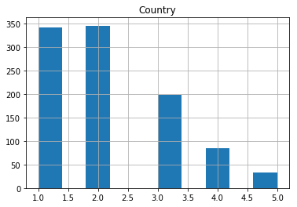

```python
# Histogram Plot
df2.hist(column='Country')
```

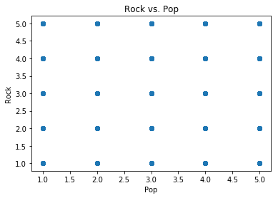

```python
# ScatterPlot
plt.title('Rock vs. Pop')
plt.xlabel('Pop')
plt.ylabel('Rock')
plt.scatter(df2.Pop, df2.Rock) # x first, then y
plt.show()
```

Scatterplots show linear and non-linear trends. This data above between Rock and Pop is the perfect example when not to use this type of plot. This type of data does not give much information because it is compressed giving us a grid of dots instead.

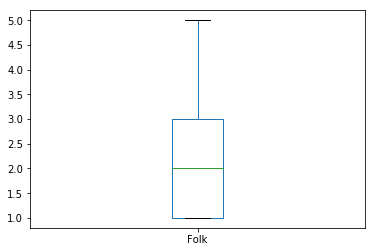

```python
#BoxPlot
df2.boxplot(column=['Folk'], grid = False)
```

## Problem 3: Descriptive Statistics

### SPECIFICATIONS

- Check for missing values. Report back what you find. If any column has missing values, remove them before moving forward.
- Pick a column and run the means, medians, and modes.
- Use the same column, but groupby a categorical variable and run the means. In a markdown cell immediately afterward, describe any differences you see in the means.
- Using a categorical column, run a frequency table using value_counts. Report back the results in a markdown cell. Also check if the resulting values are valid, given what values are possible.

```python
df3 = df.copy()
# checking for any empty variables
df3.isnull().sum()
```

```
Music                          3
Slow songs or fast songs       2
Dance                          4
Folk                           5
Country                        5
Classical music                7
Musical                        2
Pop                            3
Rock                           6
Metal or Hardrock              3
Punk                           8
Hiphop, Rap                    4
Reggae, Ska                    7
Swing, Jazz                    6
Rock n roll                    7
Alternative                    7
Latino                         8
Techno, Trance                 7
Opera                          1
Movies                         6
Horror                         2
Thriller                       1
Comedy                         3
Romantic                       3
Sci-fi                         2
War                            2
Fantasy/Fairy tales            3
Animated                       3
Documentary                    8
Western                        4
                              ..
Public speaking                2
Unpopularity                   3
Life struggles                 3
Happiness in life              4
Energy levels                  5
Small - big dogs               4
Personality                    4
Finding lost valuables         4
Getting up                     5
Interests or hobbies           3
Parents' advice                2
Questionnaires or polls        4
Internet usage                 0
Finances                       3
Shopping centres               2
Branded clothing               2
Entertainment spending         3
Spending on looks              3
Spending on gadgets            0
Spending on healthy eating     2
Age                            7
Height                        20
Weight                        20
Number of siblings             6
Gender                         6
Left - right handed            3
Education                      1
Only child                     2
Village - town                 4
House - block of flats         4
Length: 150, dtype: int64
```

I used df3.isnull().sum() to find any empty values in the columns which gave me the total sum of missing values per column. Most Values have a null value except the 6 below.

```python
# Drops all of the columns that has missing values
df3.dropna(axis=1)
```

|  | Snakes | Eating to survive | Dreams | Number of friends | Internet usage | Spending on gadgets |
| --- | --- | --- | --- | --- | --- | --- |
| 0 | 5 | 1 | 4 | 3 | few hours a day | 1 |
| 1 | 1 | 1 | 3 | 3 | few hours a day | 5 |
| 2 | 1 | 5 | 1 | 3 | few hours a day | 4 |
| 3 | 5 | 1 | 3 | 1 | most of the day | 4 |
| 4 | 1 | 1 | 3 | 3 | few hours a day | 2 |
| 5 | 2 | 2 | 3 | 3 | few hours a day | 4 |
| 6 | 5 | 1 | 3 | 3 | less than an hour a day | 1 |
| 7 | 5 | 2 | 4 | 4 | few hours a day | 3 |
| 8 | 5 | 1 | 4 | 2 | few hours a day | 3 |
| 9 | 4 | 1 | 3 | 3 | few hours a day | 2 |
| 10 | 1 | 2 | 3 | 3 | less than an hour a day | 2 |
| 11 | 5 | 1 | 3 | 4 | few hours a day | 1 |
| 12 | 3 | 3 | 3 | 3 | few hours a day | 2 |
| 13 | 4 | 2 | 4 | 3 | few hours a day | 3 |
| 14 | 5 | 1 | 4 | 5 | most of the day | 1 |
| 15 | 1 | 5 | 3 | 3 | few hours a day | 5 |
| 16 | 3 | 3 | 3 | 4 | few hours a day | 3 |
| 17 | 4 | 5 | 2 | 2 | few hours a day | 2 |
| 18 | 1 | 3 | 3 | 2 | few hours a day | 5 |
| 19 | 2 | 2 | 4 | 4 | few hours a day | 3 |
| 20 | 2 | 2 | 4 | 3 | few hours a day | 4 |
| 21 | 1 | 1 | 4 | 3 | few hours a day | 2 |
| 22 | 5 | 3 | 3 | 2 | few hours a day | 4 |
| 23 | 3 | 1 | 4 | 3 | few hours a day | 2 |
| 24 | 5 | 2 | 2 | 2 | few hours a day | 5 |
| 25 | 2 | 1 | 4 | 4 | few hours a day | 1 |
| 26 | 2 | 3 | 4 | 4 | few hours a day | 4 |
| 27 | 5 | 3 | 4 | 3 | few hours a day | 2 |
| 28 | 4 | 1 | 4 | 5 | few hours a day | 1 |
| 29 | 5 | 1 | 3 | 4 | few hours a day | 2 |
| ... | ... | ... | ... | ... | ... | ... |
| 980 | 1 | 1 | 3 | 5 | less than an hour a day | 4 |
| 981 | 4 | 2 | 3 | 2 | most of the day | 2 |
| 982 | 2 | 2 | 2 | 3 | few hours a day | 3 |
| 983 | 5 | 5 | 3 | 4 | few hours a day | 3 |
| 984 | 2 | 3 | 2 | 3 | most of the day | 4 |
| 985 | 2 | 2 | 3 | 3 | few hours a day | 3 |
| 986 | 4 | 1 | 5 | 5 | few hours a day | 1 |
| 987 | 2 | 4 | 3 | 2 | few hours a day | 4 |
| 988 | 1 | 1 | 3 | 5 | few hours a day | 5 |
| 989 | 1 | 1 | 3 | 3 | most of the day | 1 |
| 990 | 1 | 4 | 3 | 5 | few hours a day | 4 |
| 991 | 5 | 2 | 3 | 3 | most of the day | 3 |
| 992 | 3 | 1 | 3 | 3 | most of the day | 1 |
| 993 | 3 | 3 | 3 | 3 | few hours a day | 4 |
| 994 | 4 | 1 | 3 | 2 | few hours a day | 3 |
| 995 | 2 | 3 | 4 | 3 | few hours a day | 2 |
| 996 | 1 | 4 | 3 | 3 | few hours a day | 3 |
| 997 | 5 | 3 | 3 | 5 | less than an hour a day | 2 |
| 998 | 4 | 1 | 4 | 3 | few hours a day | 2 |
| 999 | 2 | 3 | 4 | 3 | few hours a day | 3 |
| 1000 | 1 | 2 | 4 | 2 | few hours a day | 4 |
| 1001 | 1 | 2 | 3 | 4 | few hours a day | 2 |
| 1002 | 1 | 4 | 2 | 4 | few hours a day | 3 |
| 1003 | 5 | 3 | 4 | 3 | few hours a day | 4 |
| 1004 | 2 | 3 | 4 | 5 | few hours a day | 4 |
| 1005 | 2 | 1 | 3 | 3 | few hours a day | 3 |
| 1006 | 1 | 1 | 3 | 3 | less than an hour a day | 5 |
| 1007 | 2 | 1 | 3 | 1 | most of the day | 2 |
| 1008 | 3 | 3 | 3 | 3 | most of the day | 3 |
| 1009 | 4 | 4 | 3 | 2 | few hours a day | 1 |

1010 rows × 6 columns

```python
df3['Dreams'].mean()
```

```
3.297029702970297
```

```python
df3['Dreams'].median()
```

```
3.0
```

```python
df3['Dreams'].mode()
```

```
0    3
dtype: int64
```

```python
df3['Dreams'].groupby(df3['Internet usage']).mean()
```

```
Internet usage
few hours a day            3.315860
less than an hour a day    3.223022
most of the day            3.266129
no time at all             3.333333
Name: Dreams, dtype: float64
```

The mean between dreams and amount of internet usage per day does not vary too much. They all average 3.2-3.3 range so there is not too big of a difference which makes me assume there is not a big correlation between dreams and amount of interent usage per day

```python
df3['Internet usage'].value_counts()
```

```
few hours a day            744
less than an hour a day    139
most of the day            124
no time at all               3
Name: Internet usage, dtype: int64
```

Using value_counts(), I created a frequency table showing how many people recorded each category for their Internet usage. 744 people reported a few hours a day, 139 people reported less than an hour a day, 124 reported most of the day, and 3 reported no time at all. To double check if the results are valid, all the reports added up are equivalent to the amount of rows there are.

## Problem 4: Lists and Dictionaries

### SPECIFICATIONS

- Create an empty dictionary called my_dict.
- Using your family or best friends' names as keys, add each person's age to the dictionary as an associated value.
- Your code must have a calcAverage function that takes two parameters: a list of a single student's scores and the weights. The function must iterate the scores and weights and calculate and return the weighted average. You may assume that students and weights are the same length.
- Your script must prompt the user for the student's name. The name must be used to extract the list of scores for that student. The script must then call the calcAverage function. The script must then print out the result like this: *Clara's final score is 48.70%.* The score must be rounded to two decimal places.
- REFLECTION. **It is not sufficient just to write the code**: You must include a clearly-labeled reflection section (in markdown) that describes in detail how your code works. Pay special attention to the function, the function's parameters, how the function works, and what the function returns.

For the problem below, I realized I can also have done it like this alternatively: students = { 'Chris': [21], 'Nick': [21], 'Dan': [20], 'Josh': [21] }

```python
my_dict = {}
```

```python
my_dict['Chris'] = 21 # Adding name with key age to the empty dictionary
```

```python
my_dict['Nick'] = 21
```

```python
my_dict['Dan'] = 20
```

```python
my_dict['Josh'] = 21
```

```python
print(my_dict) # To see what the dictionary looks like at the moment
```

```
{'Nick': 21, 'Josh': 21, 'Dan': 20, 'Chris': 21}
```

```python
# Calculate average Function
def calcAverage(scores,weights):
    avg = 0
    for i in range(0,len(scores)): # Go through the list of scores
        avg = avg + scores[i] * weights[i] #This line specifically calculates the average
    return avg
```

```python
# Creating the dictionary of students
students = {\
            "Chris":[57,40,70,61],\
            "Nick":[100,86,74,70],\
            "Dan":[63,45,60,80],\
            "Josh":[82,91,80,86]}
```

```python
# List of weights
weights = [.1,.2,.3,.4]
```

```python
name = input("Students Name:") #Prompt the user to enter a name
scores = students[name] # Use the dictonary of students
avg = round(calcAverage(scores,weights),2) #This is used to round the average value
print(name + "'s final score is {:.2f}%.".format(avg))
```

```
Chris's final score is 59.10%.
```

# Reflection

calcAverage is a function that calculates the average with the parameters scores and weights. This function goes through the dictionary of scores from the students, calculates the average, and then returns the average. The students dictionary contains all the names and scores students achieved. I then created a program with the input function that prompts the user with a message to enter a students name. After entering the name, it grabs the list with the name enterned and rounds the scores to the average value. The print function then displays a name followed by a student's average score with two decimal places.